# Sentiment Analysis

Mining user review data to determine how people feel about your product, brand, or service can be done using a technique called sentiment analysis. User reviews for apps can be analyzed to identify if the mood is positive, negative or neutral about that app. For example, positive words in an app review might include words such as 'amazing', 'friendly', 'good', 'great', and 'love'. Negative words might be words like 'malware', 'hate', 'problem', 'refund', and 'incompetent'.

### Importing Libraries

```python
import numpy as np
import pandas as pd
import seaborn as sns
```

### Reading csv files

```python
#from google.colab import files
#uploaded = files.upload()
from google.colab import drive
drive.mount('/content/drive')
```

```python
df = pd.read_csv('/content/drive/MyDrive/Data/googleplaystore_user_reviews.csv')
df.head()
```

|  | App | Translated_Review | Sentiment | Sentiment_Polarity | Sentiment_Subjectivity |
| --- | --- | --- | --- | --- | --- |
| 0 | 10 Best Foods for You | I like eat delicious food. That's I'm cooking ... | Positive | 1.00 | 0.533333 |
| 1 | 10 Best Foods for You | This help eating healthy exercise regular basis | Positive | 0.25 | 0.288462 |
| 2 | 10 Best Foods for You | NaN | NaN | NaN | NaN |
| 3 | 10 Best Foods for You | Works great especially going grocery store | Positive | 0.40 | 0.875000 |
| 4 | 10 Best Foods for You | Best idea us | Positive | 1.00 | 0.300000 |

### Data Cleaning

```python
df = df.dropna()
df.head()
```

|  | App | Translated_Review | Sentiment | Sentiment_Polarity | Sentiment_Subjectivity |
| --- | --- | --- | --- | --- | --- |
| 0 | 10 Best Foods for You | I like eat delicious food. That's I'm cooking ... | Positive | 1.00 | 0.533333 |
| 1 | 10 Best Foods for You | This help eating healthy exercise regular basis | Positive | 0.25 | 0.288462 |
| 3 | 10 Best Foods for You | Works great especially going grocery store | Positive | 0.40 | 0.875000 |
| 4 | 10 Best Foods for You | Best idea us | Positive | 1.00 | 0.300000 |
| 5 | 10 Best Foods for You | Best way | Positive | 1.00 | 0.300000 |

```python
df['Sentiment'].value_counts()
```

```
Positive    23998
Negative     8271
Neutral      5158
Name: Sentiment, dtype: int64
```

### Sentiment Polarity distribution

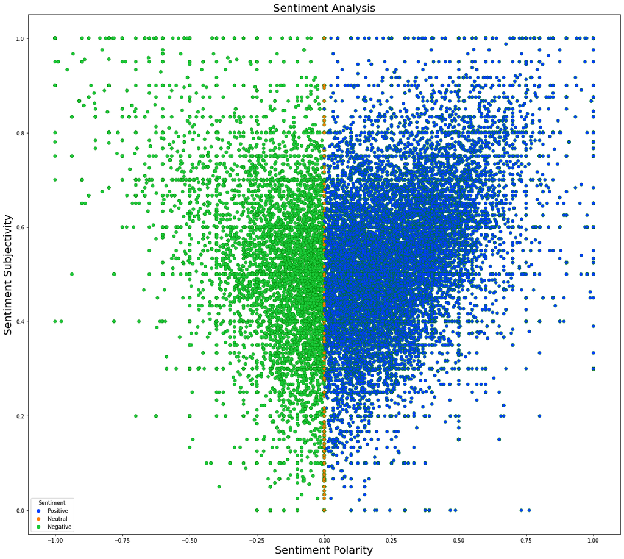

```python
import matplotlib.pyplot as plt
plt.figure(figsize=(20,18))
sns.scatterplot(df['Sentiment_Polarity'],df['Sentiment_Subjectivity'],hue=df['Sentiment'], edgecolor='green',palette="bright")
plt.xlabel('Sentiment Polarity', fontsize=20)
plt.ylabel('Sentiment Subjectivity', fontsize=20)
plt.title("Sentiment Analysis", fontsize=20)
plt.show()
```

### Reading csv File

```python
#from google.colab import files
#uploaded = files.upload()
app_df = pd.read_csv('/content/drive/MyDrive/Data/googleplaystore.csv')
app_df.head()
```

|  | App | Category | Rating | Reviews | Size | Installs | Type | Price | Content Rating | Genres | Last Updated | Current Ver | Android Ver |
| --- | --- | --- | --- | --- | --- | --- | --- | --- | --- | --- | --- | --- | --- |
| 0 | Photo Editor & Candy Camera & Grid & ScrapBook | ART_AND_DESIGN | 4.1 | 159 | 19M | 10,000+ | Free | 0 | Everyone | Art & Design | January 7, 2018 | 1.0.0 | 4.0.3 and up |
| 1 | Coloring book moana | ART_AND_DESIGN | 3.9 | 967 | 14M | 500,000+ | Free | 0 | Everyone | Art & Design;Pretend Play | January 15, 2018 | 2.0.0 | 4.0.3 and up |
| 2 | U Launcher Lite – FREE Live Cool Themes, Hide ... | ART_AND_DESIGN | 4.7 | 87510 | 8.7M | 5,000,000+ | Free | 0 | Everyone | Art & Design | August 1, 2018 | 1.2.4 | 4.0.3 and up |
| 3 | Sketch - Draw & Paint | ART_AND_DESIGN | 4.5 | 215644 | 25M | 50,000,000+ | Free | 0 | Teen | Art & Design | June 8, 2018 | Varies with device | 4.2 and up |
| 4 | Pixel Draw - Number Art Coloring Book | ART_AND_DESIGN | 4.3 | 967 | 2.8M | 100,000+ | Free | 0 | Everyone | Art & Design;Creativity | June 20, 2018 | 1.1 | 4.4 and up |

• Plotting boxplot for sentiment polarity scores of user reviews for paid and free apps

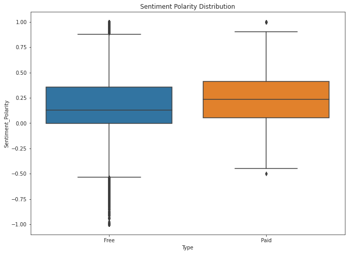

```python
#app_df = pd.read_csv(io.BytesIO(uploaded['googleplaystore.csv']))

# Join and merge the two dataframe
merged_df = pd.merge(app_df,df, on ='App', how = "inner")

# Drop NA values from Sentiment and Translated_Review columns
merged_df = merged_df.dropna(subset=['Sentiment', 'Translated_Review'])

sns.set_style('ticks')
fig, ax = plt.subplots()
fig.set_size_inches(11, 8)

# User review sentiment polarity for paid vs. free apps
ax = sns.boxplot(x =merged_df['Type'], y =merged_df['Sentiment_Polarity'])
ax.set_title('Sentiment Polarity Distribution')
```

By plotting sentiment polarity scores of user reviews for paid and free apps, we observe that free apps receive a lot of harsh comments, as indicated by the outliers on the negative y-axis. Reviews for paid apps appear never to be extremely negative. This may indicate something about app quality, i.e., paid apps being of higher quality than free apps on average. The median polarity score for paid apps is a little higher than free apps, thereby syncing with our previous observation.

## Finding most commonly used words

```python
import re
import nltk
from nltk.corpus import stopwords
from nltk.stem.porter import PorterStemmer
from nltk.tokenize import word_tokenize
```

```python
df["index"] = range(0,37427)
df = df.set_index("index")
df.head()
```

| index | App | Translated_Review | Sentiment | Sentiment_Polarity | Sentiment_Subjectivity |
| --- | --- | --- | --- | --- | --- |
| 0 | 10 Best Foods for You | I like eat delicious food. That's I'm cooking ... | Positive | 1.00 | 0.533333 |
| 1 | 10 Best Foods for You | This help eating healthy exercise regular basis | Positive | 0.25 | 0.288462 |
| 2 | 10 Best Foods for You | Works great especially going grocery store | Positive | 0.40 | 0.875000 |
| 3 | 10 Best Foods for You | Best idea us | Positive | 1.00 | 0.300000 |
| 4 | 10 Best Foods for You | Best way | Positive | 1.00 | 0.300000 |

```python
import nltk
nltk.download('stopwords')
STOPWORDS = set(stopwords.words('english'))
corpus=[]
for i in range(0,37427):
    review = re.sub('[^a-zA-Z]', ' ',df['Translated_Review'][i])
    review = re.sub('[/(){}\[\]\|@!,;]', ' ',df['Translated_Review'][i])
    review = re.sub('[^0-9a-z #+_♥️]', ' ',df['Translated_Review'][i])#Remove bad symbols
    review = review.lower()
    review = review.split()
    stemmer = PorterStemmer()
    review = [stemmer.stem(token) for token in review if token not in STOPWORDS]
    review=' '.join(review)
    corpus.append(review)
corpus
```

```python
words = []
Sentiment_Polarity=[]
for i in range(0,len(corpus)):
    words = words + (re.findall(r'\w+', corpus[i]))# words cantain all the words in the dataset
    Sentiment_Polarity.append
words
```

```python
from collections import Counter
words_counts = Counter(words)
```

```python
most_common_words = sorted(words_counts.items(), key=lambda x: x[1], reverse=True)
most_commmom_wordList = []
most_commmom_CountList = []
for x, y in most_common_words:
    most_commmom_wordList.append(x)
    most_commmom_CountList.append(y)
```

Most common 30 words used in reviews

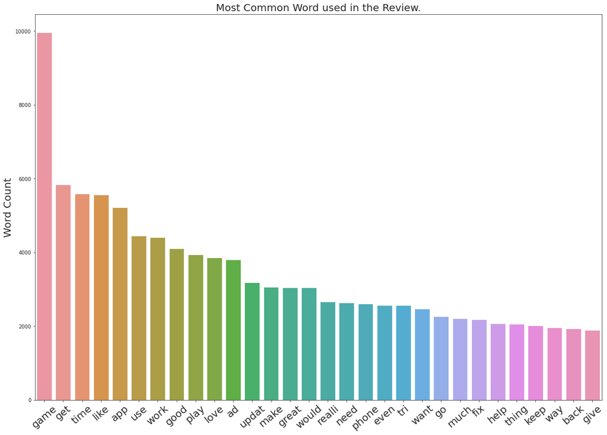

```python
plt.figure(figsize=(20,14))
plot = sns.barplot(np.arange(30), most_commmom_CountList[0:30]) #width=0.35)
plt.ylabel('Word Count',fontsize=20)
plt.xticks(np.arange(30), most_commmom_wordList[0:30], fontsize=20, rotation=40)
plt.title('Most Common Word used in the Review.', fontsize=20)
plt.show()
```

• We can also find most commonly used 30 words in positive, negative and neutral reviews

```python
k = most_commmom_wordList[0:30]
Sentiment_Polarity=[]
Positive=[]
Neutral=[]
Negative=[]
for i in k:
    Sentiment=[]
    for z in corpus:
        #if i in z:
            #Sentiment.append(Data['Sentiment_Polarity'][corpus.index(z)])
    #Sentiment_Polarity.append(Sentiment)
        if i in z and df['Sentiment'][corpus.index(z)]=='Positive':
            Positive.append(i)
        if i in z and df['Sentiment'][corpus.index(z)]=='Neutral':
            Neutral.append(i)
        if i in z and df['Sentiment'][corpus.index(z)]=='Negative':
            Negative.append(i)
```

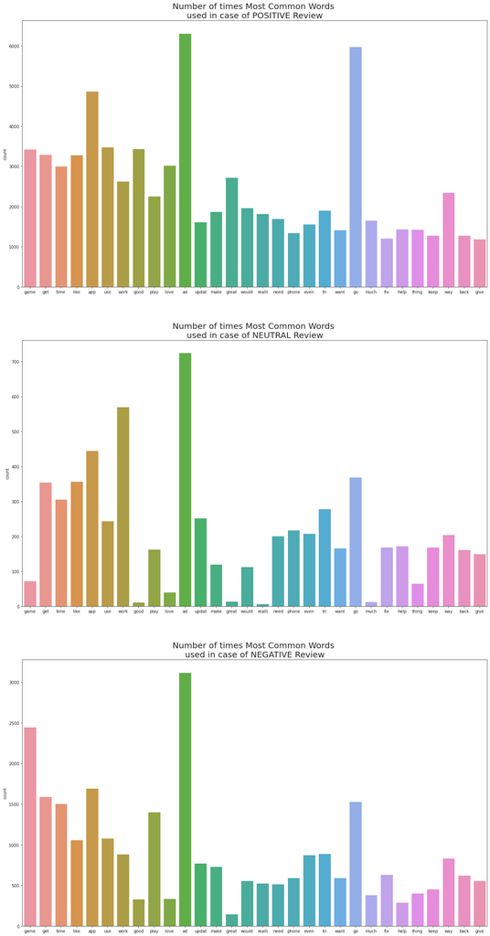

```python
f,ax = plt.subplots(3,1,figsize=(20,40))
c1 = sns.countplot(Positive, ax=ax[0])
c2 = sns.countplot(Neutral,ax=ax[1])
c3 = sns.countplot(Negative,ax=ax[2])
ax[0].set_title("Number of times Most Common Words \nused in case of POSITIVE Review",fontsize=20)
ax[1].set_title("Number of times Most Common Words \nused in case of NEUTRAL Review",fontsize=20)
ax[2].set_title("Number of times Most Common Words \nused in case of NEGATIVE Review",fontsize=20)
plt.show()
```

## Word Cloud

```python
df['Sentiment'].unique()
```

```
array(['Positive', 'Neutral', 'Negative'], dtype=object)
```

```python
x=[]
for i in df['Sentiment']:
    if i=='Positive':
        x.append(0)
    elif i=='Neutral':
        x.append(1)
    else :
        x.append(2)
```

```python
df['y']=x
```

```python
df.head()
```

| index | App | Translated_Review | Sentiment | Sentiment_Polarity | Sentiment_Subjectivity | y |
| --- | --- | --- | --- | --- | --- | --- |
| 0 | 10 Best Foods for You | I like eat delicious food. That's I'm cooking ... | Positive | 1.00 | 0.533333 | 0 |
| 1 | 10 Best Foods for You | This help eating healthy exercise regular basis | Positive | 0.25 | 0.288462 | 0 |
| 2 | 10 Best Foods for You | Works great especially going grocery store | Positive | 0.40 | 0.875000 | 0 |
| 3 | 10 Best Foods for You | Best idea us | Positive | 1.00 | 0.300000 | 0 |
| 4 | 10 Best Foods for You | Best way | Positive | 1.00 | 0.300000 | 0 |

```python
df['y'].value_counts()
```

```
0    23998
2     8271
1     5158
Name: y, dtype: int64
```

• We can understand the words used most frequently in whole dataset by creating a word cloud as :

```python
unique_words=[]
total_words=[]
for i in df['Translated_Review'].str.split():
    for j in i:
        total_words.append(j)
        if i not in unique_words:
            unique_words.append(i)
len(unique_words),len(total_words)
```

```
(27994, 686808)
```

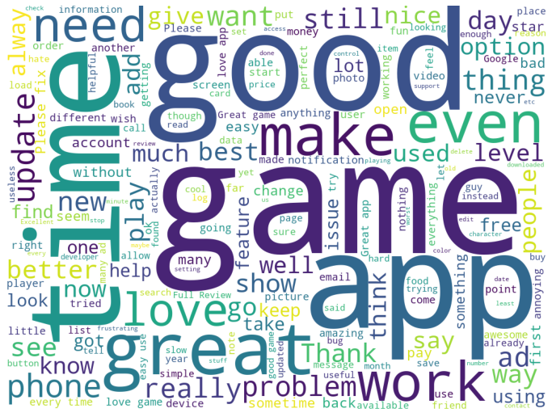

```python
import matplotlib.pyplot as plt
from wordcloud import WordCloud
plt.subplots(figsize=(12,12))
wordcloud=WordCloud(background_color="white",width=1024,height=768).generate(" ".join(total_words))
plt.imshow(wordcloud)
plt.axis("off")
plt.show()
```

## Model

• We can build a model to predict whether a given review is positive, negative or neutral. To predict this sentiment we used random forest model

```python
x= df['Translated_Review']
y=df['Sentiment']
```

```python
y.unique()
```

```
array(['Positive', 'Neutral', 'Negative'], dtype=object)
```

### Train - Test split dataset

```python
from sklearn.model_selection import train_test_split
# Split data into training and test sets
X_train, X_test, y_train, y_test = train_test_split(x,y,test_size=0.2)
```

```python
print(X_train.shape, X_test.shape, y_train.shape, y_test.shape)
```

```
(29941,) (7486,) (29941,) (7486,)
```

### Count vectorization

```python
from sklearn.feature_extraction.text import CountVectorizer
# Fit the CountVectorizer to the training data
vect = CountVectorizer(stop_words='english',strip_accents='ascii',max_features=1000).fit(X_train)
len(vect.get_feature_names())
```

```
1000
```

```python
X_train.shape
```

```
(29941,)
```

```python
# transform the documents in the training data to a document-term matrix
X_train_vectorized = vect.transform(X_train)
X_train_vectorized
```

```
<29941x1000 sparse matrix of type '<class 'numpy.int64'>'
	with 247602 stored elements in Compressed Sparse Row format>
```

```python
X_train_vectorized.toarray()
```

```
array([[0, 0, 0, ..., 0, 0, 0],
       [0, 0, 0, ..., 0, 0, 0],
       [0, 0, 0, ..., 0, 0, 0],
       ...,
       [0, 0, 0, ..., 0, 0, 0],
       [0, 0, 0, ..., 0, 0, 0],
       [0, 0, 0, ..., 0, 0, 0]])
```

```python
x_test_transformed = vect.transform(X_test)
```

### Random Forest

```python
from sklearn.ensemble import RandomForestClassifier
rf=RandomForestClassifier(random_state=121)
rf.fit(X_train_vectorized,y_train)
rf.predict(x_test_transformed)

pd.DataFrame([X_test.values,rf.predict(x_test_transformed)]).T

rf.predict(x_test_transformed)[1:20] # first 20 sentiment prediction
```

```
array(['Positive', 'Positive', 'Positive', 'Positive', 'Positive',
       'Positive', 'Positive', 'Positive', 'Positive', 'Positive',
       'Positive', 'Positive', 'Positive', 'Positive', 'Neutral',
       'Neutral', 'Positive', 'Positive', 'Positive'], dtype=object)
```

### Final Prediction

```python
test=vect.transform(["the app is nice fantastic in using and fun to use"])

rf.predict(test)
```

```
array(['Positive'], dtype=object)
```

```python
score = rf.score(x_test_transformed,y_test)
print(score)
```

```
0.8967405824205184
```